# An application: SLGP-based prediction of temperature distributions at meteorological stations in Switzerland.

Athénaïs Gautier

Last revised - October 2024

## Introduction

In this vignette, we apply the Spatial Logistic Gaussian Process (SLGP) model to estimate temperature distributions at meteorological stations across Switzerland. This example illustrates SLGP’s capacity to model spatial temperature variations based on location-specific factors, such as latitude, longitude, and altitude, using real meteorological data made available by MeteoSwiss (Meteorology and MeteoSwiss 2019).

## Data Loading and Visualization

We begin by loading and visualizing the dataset of daily average temperatures at 29 meteorological stations across Switzerland. This initial step provides insight into temperature variability across different regions and altitudes.

```r
# Dataset
X <- read.csv("./data_meteo.txt", encoding = "latin1")
stations <- unique(X[, c(1, 8:13)])

world_map <- map_data("world", region="Switzerland") #Load a map
```

To ensure a smooth modeling process, we prepare the dataset by renaming variables for clarity and storing their respective value ranges. This step facilitates easier handling of variables in subsequent modeling steps.

```r
#Ready to normalise
range_temp <- c(-30, 40)
range_lat <- range(topography$lat)
range_long <- range(topography$long)
range_height <- c(0, 4810)

#Extract the relevant columns
samples <- X[, c("tre200d0", "Latitude", "Longitude", "Station.height.m..a..sea.level")]
colnames(samples) <- c("Temperature", "Latitude", "Longitude", "Altitude")
summary(samples)
```

```
##   Temperature         Latitude       Longitude        Altitude
##  Min.   :-21.600   Min.   :45.87   Min.   :6.128   Min.   : 273
##  1st Qu.:  1.500   1st Qu.:46.46   1st Qu.:7.330   1st Qu.: 485
##  Median :  7.500   Median :46.81   Median :8.333   Median : 958
##  Mean   :  7.584   Mean   :46.73   Mean   :8.246   Mean   :1109
##  3rd Qu.: 13.800   3rd Qu.:47.02   3rd Qu.:9.175   3rd Qu.:1605
##  Max.   : 29.600   Max.   :47.54   Max.   :9.879   Max.   :3571
```

We will use data from stations outside the canton of Bern for training the SLGP model, leaving the remaining stations as a test set to assess generalization. The model will predict temperature distributions based on the latitude, longitude, and altitude of each station.

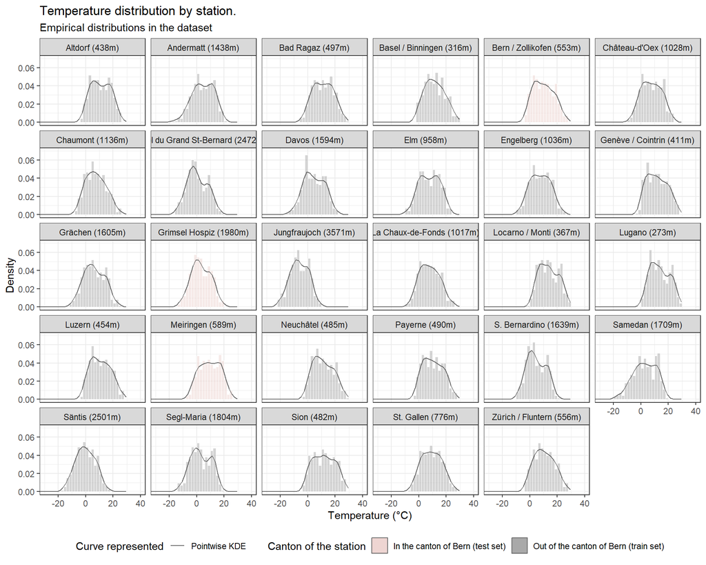

Empirical distributions of temperatures at the considered stations

## Initial SLGP Estimation with Arbitrary Hyperparameters

To understand the model’s baseline behavior, we perform an initial SLGP estimation using arbitrary hyperparameters. This first run provides insight into the model’s ability to capture the temperature distribution’s overall structure.

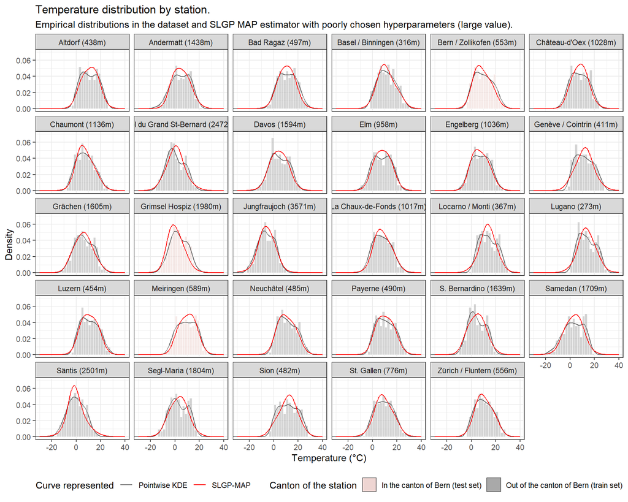

A SLGP estimation with poorly chosen lengthscale (too big)

The initial results show that while the model captures the general support of the temperature distribution, it fails to capture finer details, such as multi-modalities in certain distributions. This limitation likely arises from using a large length scale, which oversmooths small-scale variations.

To investigate further, we run the SLGP with a much smaller length scale. This adjustment helps reveal the model’s response to hyperparameter tuning and allows us to compare results across different spatial aggregation levels.

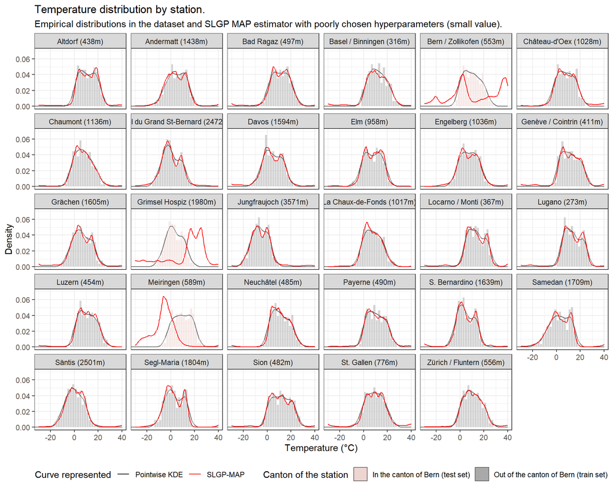

A SLGP estimation with poorly chosen lengthscale (too small)

This time, while the model provides accurate temperature estimates at stations within the training set, it generalizes poorly to test stations. Using too small a length scale restricts the model’s spatial aggregation, limiting the reach of spatial information to a very local scope.

## Selecting an Optimal Length Scale with Grid Search

To balance between overly small and overly large length scales, we propose selecting an appropriate length-scale hyperparameter via a grid search, aiming to find a balanced length scale that performs well across different spatial contexts. This grid search involves computing the (unnormalized) posterior for various candidate length scales, and selecting the hyperparameter value that maximizes it. This approach seeks a compromise between the previously observed limitations: length scales that are too small, which limit spatial aggregation, and those that are too large, which oversmooth local variations.

In Switzerland, we expect altitude to be the most significant factor influencing temperature variation, often more so than latitude and longitude. Consequently, we opted to share a single length scale for latitude and longitude, thereby slightly reducing the computational cost of estimation and simplifying the visualization of the results. For clarity, the code presented here is structured as a single loop; however, in practical applications, we parallelized the computations to improve efficiency.

```r
dinvgamma <- function(x, alpha=3, beta=0.3) {
  ifelse(x<=0, 0, (beta^alpha / gamma(alpha)) * x^(-alpha - 1) * exp(-beta / x))
}

df_res <- data.frame(lt=NA, lx1=NA, lx2=NA, lx3=NA, value=NA)[c(0), ]
for(lx1 in seq(0.05, 0.5, 0.05)){
  lx2 <- lx1
  for(lx3 in seq(0.05, 0.5, 0.05)){
    for(lt in  seq(0.05, 0.3, 0.025)){
      starting_lengthscale <- c(lt, lx1, lx2, lx3)
      names(starting_lengthscale) <- paste0("Lengthscale ", c("t", name_index))
      print(starting_lengthscale)

      mod <- slgp(Temperature~.,
                  data=samplesTrain,
                  method="MAP",
                  basisFunctionsUsed = "RFF",
                  interpolateBasisFun="nothing",
                  hyperparams = list(lengthscale=starting_lengthscale,
                                     sigma2=1),
                  predictorsUpper= c(range_lat[2],
                                     range_long[2],
                                     range_height[2]),
                  predictorsLower= c(range_lat[1],
                                     range_long[1],
                                     range_height[1]),
                  responseRange= range_temp,
                  sigmaEstimationMethod = "heuristic",
                  seed=1,
                  opts_BasisFun = list(nFreq=250,
                                       MatParam=5/2))
      pred <- predictSLGP_newNode(SLGPmodel=mod,
                                  newNodes = samplesTest)
      logprior <- log(dinvgamma(lx1))+log(dinvgamma(lx2))+log(dinvgamma(lx3))+log(dinvgamma(lt))
      df_res <- rbind(dfres, c(starting_lengthscale, -sum(log(pred$pdf_1))-logprior))
    }
  }
}
save(df_res, file="resultsMeteo.RData" )
```

We can now display the resulting optimisation profile.

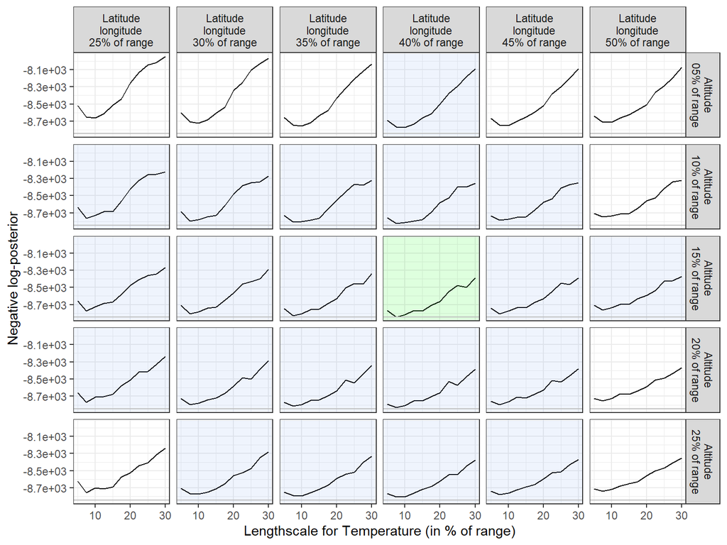

Optimisation profile for the SLGP’s lengthscales on the meteorological application

Using the optimal length scale hyperparameter identified in the grid search, we perform the final SLGP estimation. This provides the best compromise between local accuracy and generalization, as shown by improved prediction results at the test stations.

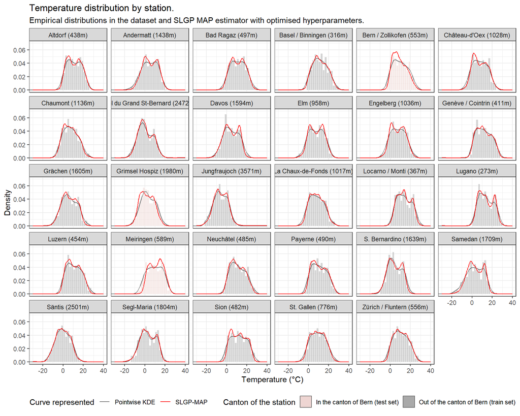

A SLGP estimation with optimally chosen lengthscale (grid-search)

```r
load(file="resultsMeteo.RData" )

lengthscale <- as.numeric(df_res[which.min(df_res$value), 1:4])
model3 <- slgp(Temperature~.,
               data=samples[!samples$inCantonBE, 1:4],
               method="MCMC",
               basisFunctionsUsed = "RFF",
               interpolateBasisFun="nothing",
               hyperparams = list(lengthscale=lengthscale,
                                  sigma2=1),
               predictorsUpper= c(range_lat[2],
                                  range_long[2],
                                  range_height[2]),
               predictorsLower= c(range_lat[1],
                                  range_long[1],
                                  range_height[1]),
               responseRange= range_temp,
               sigmaEstimationMethod = "heuristic",
               seed=1,
               opts_BasisFun = list(nFreq=250,
                                    MatParam=5/2),
               opts = list(stan_chains=2, stan_iter=1000))
model3MAP <- slgp(Temperature~.,
                  data=samples[!samples$inCantonBE, 1:4],
                  method="MAP",
                  basisFunctionsUsed = "RFF",
                  interpolateBasisFun="nothing",
                  hyperparams = list(lengthscale=lengthscale,
                                     sigma2=1),
                  predictorsUpper= c(range_lat[2],
                                     range_long[2],
                                     range_height[2]),
                  predictorsLower= c(range_lat[1],
                                     range_long[1],
                                     range_height[1]),
                  responseRange= range_temp,
                  sigmaEstimationMethod = "heuristic",
                  seed=1,
                  opts_BasisFun = list(nFreq=250,
                                       MatParam=5/2))

save(model3, model3MAP, file="ModelOptimizedLen.RData")
```

## Visualising results at some stations both in and out of the training set

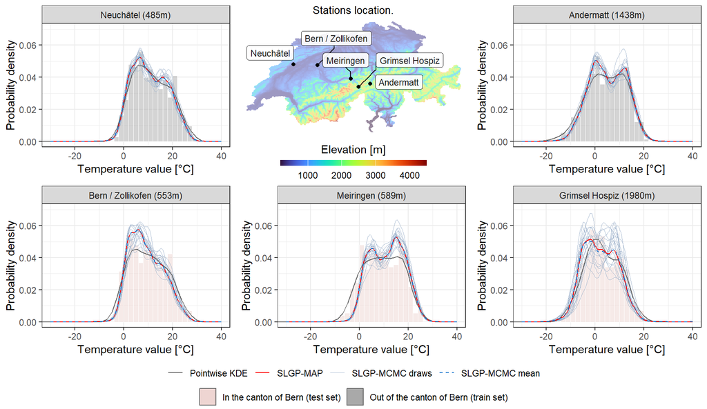

SLGP estimation for some stations both in the training set (=stations out of the Canton of Bern) and in the test set (=stations in the Canton of Bern)

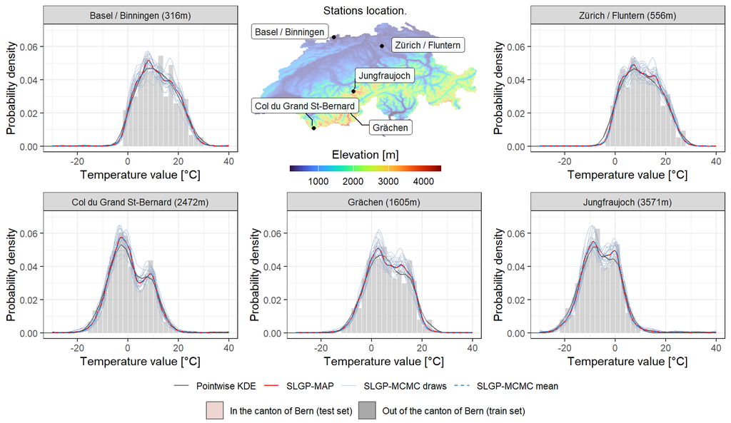

SLGP estimation for some other stations in the training set (=stations out of the Canton of Bern).

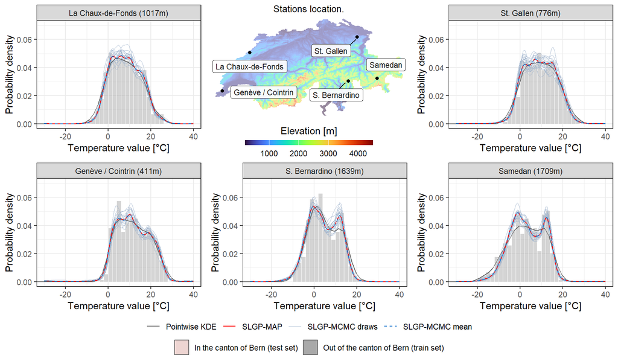

SLGP estimation for some other stations in the training set (=stations out of the Canton of Bern).

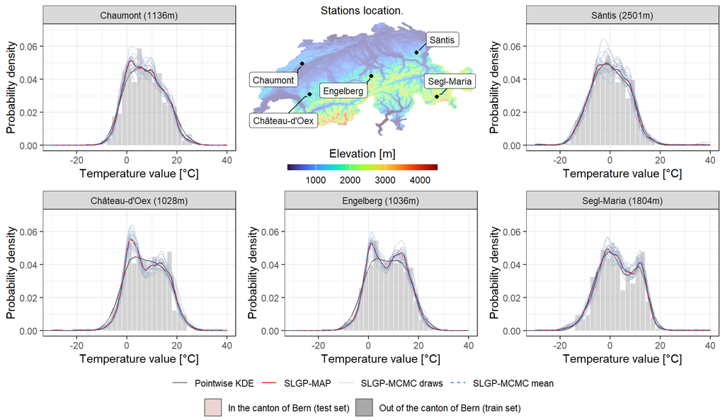

SLGP estimation for some other stations in the training set (=stations out of the Canton of Bern).

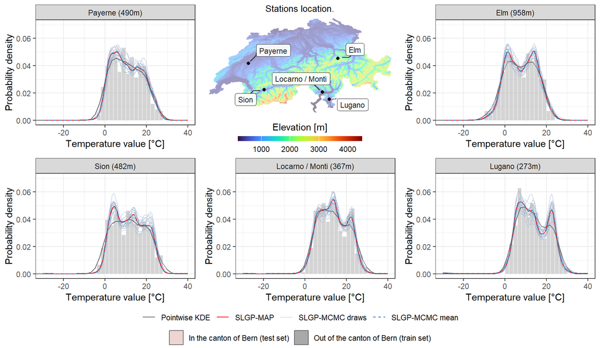

SLGP estimation for some other stations in the training set (=stations out of the Canton of Bern).

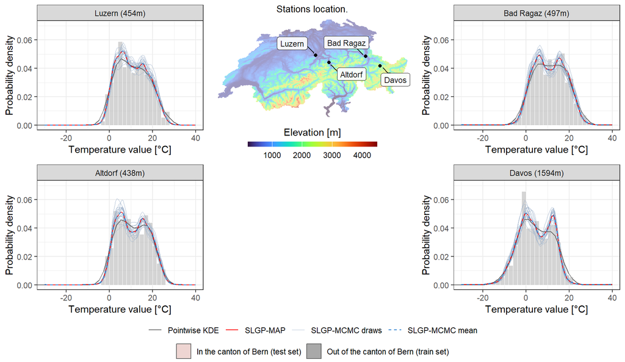

SLGP estimation for some other stations in the training set (=stations out of the Canton of Bern).

# Leveraging SLGP estimators for complex inference

Predict the MAP estimator over all of Switzerland.

```r
df <- topography
colnames(df) <- c("Longitude", "Latitude", "Altitude")

disc_long <- 201
disc_lat <- 201
df <- df %>%
  mutate(Longitude=(Longitude-range_long[1])/diff(range_long),
         Latitude=(Latitude-range_lat[1])/diff(range_lat))%>%
  mutate(Longitude=round(Longitude*disc_long)/(disc_long),
         Latitude=round(Latitude*disc_lat)/(disc_lat))%>%
  group_by(Longitude, Latitude) %>%
  summarise(Altitude=median(Altitude), .groups="keep") %>%
  ungroup()%>%
  mutate(Longitude=Longitude*diff(range_long)+range_long[1],
         Latitude=Latitude*diff(range_lat)+range_lat[1]) %>%
  data.frame()
df2 <- expand.grid(seq(range_temp[1], range_temp[2],, 141), seq(nrow(df)))
df2 <- cbind(df[df2$Var2, ], df2$Var1)
colnames(df2)[4] <- "Temperature"

dfSwissMAP<- data.frame()
rep <- 3*47
n <- nrow(df2)/rep
# Start time
start_time <- Sys.time()
for(i in seq(rep)){
  # Time at the start of each iteration
  iter_start_time <- Sys.time()
  cat(i, "\n")
  temp <- predictSLGP_newNode(SLGPmodel=model3MAP,
                              newNodes = df2[1:n  + (i-1)*n, ],
                              nDiscret=101)
  dfSwissMAP <- rbind(dfSwissMAP, temp)

  # Calculate elapsed time since the beginning in minutes
  elapsed_time <- as.numeric(difftime(Sys.time(), start_time, units = "mins"))
  iter_time <- as.numeric(difftime(Sys.time(), iter_start_time, units = "mins"))

  if(i%%3==0){
    cat("Saved just in case at ", i%/%3, "/47\n")
    save(dfSwissMAP, file="predictionInSwitzerlandMAP.RData")
  }
  # Print elapsed time and iteration time
  cat("Total elapsed time:", elapsed_time,
      "mins\nTime for this iteration:", iter_time, "mins\n\n")
}
save(dfSwissMAP, file="predictionInSwitzerlandMAP.RData")
```

Predict the MCMC estimations over all of Switzerland.

```r
df <- topography
colnames(df) <- c("Longitude", "Latitude", "Altitude")

disc_long <- 101
disc_lat <- 101
df <- df %>%
  mutate(Longitude=(Longitude-range_long[1])/diff(range_long),
         Latitude=(Latitude-range_lat[1])/diff(range_lat))%>%
  mutate(Longitude=round(Longitude*disc_long)/(disc_long),
         Latitude=round(Latitude*disc_lat)/(disc_lat))%>%
  group_by(Longitude, Latitude) %>%
  summarise(Altitude=median(Altitude), .groups="keep") %>%
  ungroup()%>%
  mutate(Longitude=Longitude*diff(range_long)+range_long[1],
         Latitude=Latitude*diff(range_lat)+range_lat[1]) %>%
  data.frame()
df2 <- expand.grid(seq(range_temp[1], range_temp[2],, 141), seq(nrow(df)))
df2 <- cbind(df[df2$Var2, ], df2$Var1)
colnames(df2)[4] <- "Temperature"

rep <- 47*3
n <- nrow(df2)/rep
# Start time
start_time <- Sys.time()
for(i in seq(rep)){
  # Time at the start of each iteration
  iter_start_time <- Sys.time()
  cat(i, "\n")
  temp <- predictSLGP_newNode(SLGPmodel=model3,
                              newNodes = df2[1:n  + (i-1)*n, ],
                              nDiscret=201)

  # Calculate elapsed time since the beginning in minutes
  elapsed_time <- as.numeric(difftime(Sys.time(), start_time, units = "mins"))
  iter_time <- as.numeric(difftime(Sys.time(), iter_start_time, units = "mins"))

  save(temp, file = paste0("./SavedData/predictionInSwitzerlandMCMC_", i, ".RData"))

  # Print elapsed time and iteration time
  cat("Total elapsed time:", elapsed_time,
      "mins\nTime for this iteration:", iter_time, "mins\n\n")

}
gc()
```

… And now, let us use these!

## Temperature-Based Localisation in Switzerland: A Proof of Concept.

In this proof of concept, we demonstrate an “inverse problem” approach: given a temperature observation, we use the MAP (Maximum A Posteriori) estimator of the Spatial Logistic Gaussian Process (SLGP) model to identify likely regions in Switzerland where this temperature could have been observed. This allows us to infer potential locations based on specific temperature measurements.

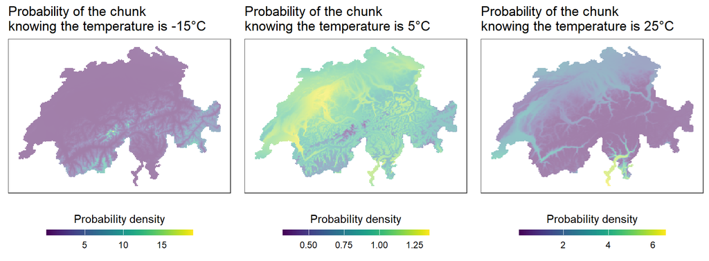

An inverse problem solved with SLGP modelling: temeprature based localisation

These results are consistent with Switzerland’s diverse geography:

- *Cold Temperatures (e.g., -15°C):* The SLGP modelling predominantly identifies locations in the Alps and at high altitudes, where cold conditions are common due to elevation. This aligns with our expectation, as the high Alpine summits and mountainous regions experience colder temperatures.
- *Moderate Temperatures (e.g., 5°C):* The SLGP MAP estimator shows a broader range of possible locations, including the Swiss Plateau and parts of Ticino (center-south of Switzerland). Additionally, moderate temperatures are also observed in mountainous regions, provided they aren’t at very high altitudes.
- *Warm Temperatures (e.g., 25°C):* The model highlights low-altitude areas like the Swiss Plateau and valleys in Ticino as likely locations for warmer temperatures. The southern slopes of the Alps, such as those in Ticino, experience a warmer climate due to the influence of southern climate patterns. This analysis rules out higher mountainous areas, as such temperatures are unusual at high elevations.

This approach offers a sight into the potential of SLGP for solving stochastic inverse problems.

## Probabilistic prediction of quantities of interest

We begin by loading the predictions of our SLGP model over Switzerland and visualise the slices considered on a map of the country.

```r
# Recombine chunks
data_chunks <- list()

for (i in 1:141) {  # Replace with actual number of chunks
  load(paste0("./SavedData/predictionInSwitzerlandMCMC_", i, ".RData"))
  data_chunks[[i]] <- temp
}

# Recombine all chunks into a single object if it's a data frame or list
dfSwissMCMC <- do.call("rbind", data_chunks)  # Adjust based on data structure
rm(data_chunks)
gc()
```

We select a slice for our visualisation. Here, we decided to take one slice that would cross through 4 stations.

[output not shown]

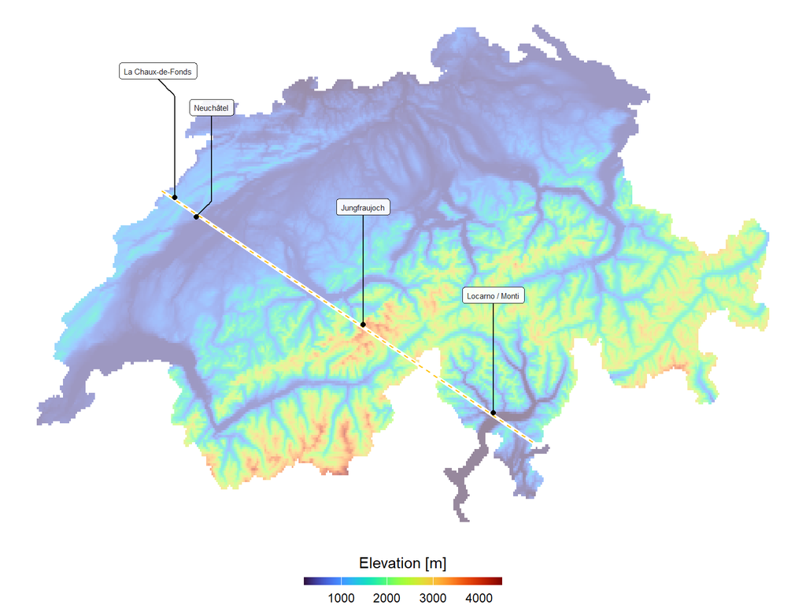

A slice across Switzerland

We project on this line and compute our quantities of interest (the quantiles).

```r
# Extract the chunks on the slice and project them in 1D
df_plot_meteo3 <- subset(df_plot_meteo2, df_plot_meteo2$subset1)
df_plot_meteo3$x2 <- (df_plot_meteo3$Latitude - range_lat[1])/diff(range_lat)
df_plot_meteo3$x1 <- (df_plot_meteo3$Longitude - range_long[1])/diff(range_long)
# line y=-1.05 x+ 0.85
library(StereoMorph)
orth_vect <- orthogonalProjectionToLine(df_plot_meteo3[, c("x1", "x2")], l1 = c(0, intercept1),
                                        l2 = c(1, -slope1+intercept1))
df_plot_meteo3$x1proj <- orth_vect[, 1]
df_plot_meteo3$x2proj <- orth_vect[, 2]

dir1 <- c(1, -slope1)
dir1 <- dir1 / sqrt(sum(dir1^2))
df_plot_meteo3$place_on_line <- apply(df_plot_meteo3[, c("x1proj", "x2proj")],
                                      1, function(u) {
                                        return(sum((u - c(0, intercept1)) * dir1))
                                      })
r1 <- range(df_plot_meteo3$place_on_line)
df_plot_meteo3$place_on_line <- (df_plot_meteo3$place_on_line-r1[1])/diff(r1)

df_plot_meteo3 <-  df_plot_meteo3%>%
  dplyr::select(-x1proj, -x2proj, -x1, -x2, -subset1, -subset2)%>%
  pivot_longer(-c("Latitude", "Longitude", "Altitude", "Temperature", "place_on_line", "Station"))%>%
  mutate(simu=substr(name, 5, 11),
         valuepdf=value) %>%
  group_by(Latitude, Longitude, Altitude, simu)%>%
  arrange(Temperature) %>%   # Sort by ascending Temperature within groups
  mutate(valuecdf=cumsum(value))%>%
  mutate(valuecdf=valuecdf-min(valuecdf))%>%
  mutate(valuecdf=valuecdf/max(valuecdf))%>%
  ungroup()%>%
  dplyr::select(-c("name", "value"))%>%
  data.frame()

df_plot_meteo_summary_1 <- df_plot_meteo3 %>%
  group_by(place_on_line, simu)%>%
  summarise(Altitude=mean(Altitude),
            mean = mean(Temperature*valuepdf),
            Station = ifelse(all(is.na(Station)), NA, unique(na.omit(Station))),
            q10 = (Temperature[which.min(abs(valuecdf-0.1))])[1],
            q20 = (Temperature[which.min(abs(valuecdf-0.2))])[1],
            q30 = (Temperature[which.min(abs(valuecdf-0.3))])[1],
            q40 = (Temperature[which.min(abs(valuecdf-0.4))])[1],
            q50 = (Temperature[which.min(abs(valuecdf-0.5))])[1],
            q60 = (Temperature[which.min(abs(valuecdf-0.6))])[1],
            q70 = (Temperature[which.min(abs(valuecdf-0.7))])[1],
            q80 = (Temperature[which.min(abs(valuecdf-0.8))])[1],
            q90 = (Temperature[which.min(abs(valuecdf-0.9))])[1],
            .groups="keep")%>%
  ungroup()%>%
  data.frame()


stations_other <- subset(df_plot_meteo_summary_1,
                         !is.na(df_plot_meteo_summary_1$Station))
stations_other <- subset(stations_other,
                         stations_other$simu==1)
```

We visualise the topographic profile of the slice with the location of the stations alongside it, as well as our probabilistic joint prediction of the Temperature quantiles along this slice.

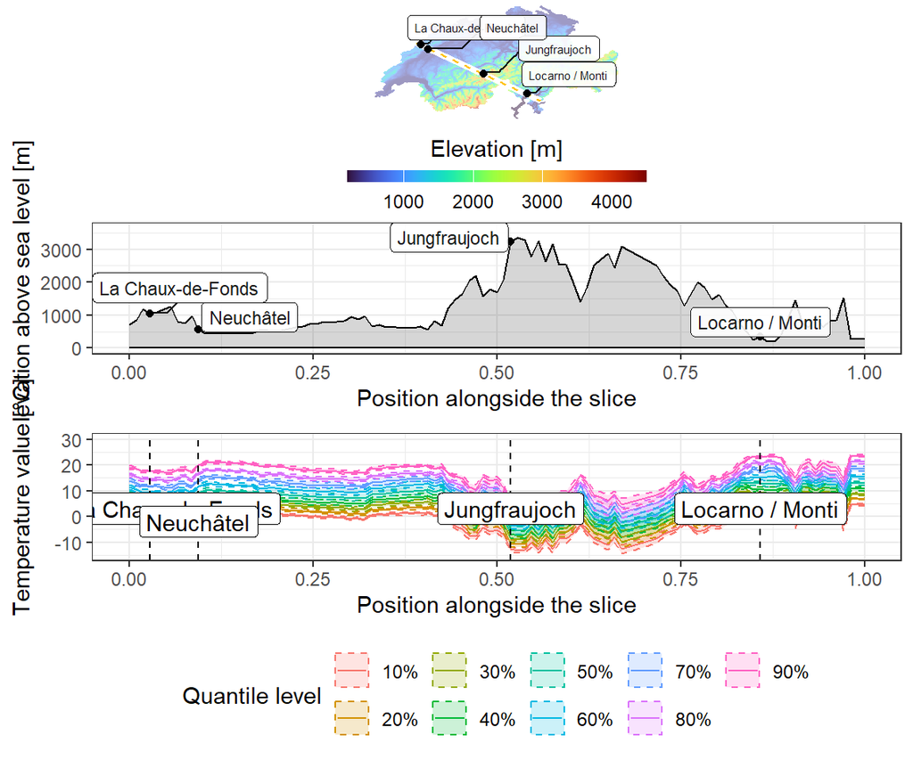

A slice across Switzerland: Location on a map, Altitude Profile, Simultaneous quantile prediction and associated uncertainty

Of course, we can also simply visualise directly some quantities of interest (such as mean expected temperature, mean quantile) and the associated point-wise uncertainty (standard deviation, inter-quartile range) over the map of Switzerland.

We perform the necessary computations

```r
df_plot_meteo2 <- df_plot_meteo2 %>%
  dplyr::select(-subset1, -subset2, -Station)%>%
  group_by(Latitude, Longitude, Altitude)%>%
  arrange(Temperature)%>%
  mutate(ID = cur_group_id()) %>%
  ungroup()%>%
  arrange(ID, Temperature)
```

```r
t <- as.numeric(df_plot_meteo2$Temperature[1:141])
value_cdf <- sapply(seq(1000), function(i){
  print(i)
  unlist(tapply(as.matrix(df_plot_meteo2[, 4+i]), INDEX=df_plot_meteo2$ID, function(pdf){
    cdf <-  cumsum(pdf)
    r <- range(cdf)
    cdf <- ((cdf-r[1])/(r[2]-r[1]))
    # invcdf <- approx(x=cdf, y=t, xout=c(0.1, 0.5, 0.9))
    return(cdf)
  }))
})
save(value_cdf, file="valuesCDFOverSwitzerland.RData")

qtyOfInt1 <- sapply(seq(1000), function(i){
  print(i)
  unlist(tapply(as.matrix(df_plot_meteo2[, 4+i]), INDEX=df_plot_meteo2$ID, function(pdf){
    m <- sum(t*pdf)/sum(pdf)
    return(m)
  }))
})
qtyOfInt2 <- sapply(seq(1000), function(i){
  print(i)
  unlist(tapply(value_cdf[, i], INDEX=df_plot_meteo2$ID, function(cdf){
    invcdf <- approx(x=cdf, y=t, xout=c(0.1, 0.5, 0.9))$y
    return(invcdf)
  }))
})
namesVec <- c(rep("Expected value", nrow(qtyOfInt1)),
              rep(c("Quantile: 10%", "Quantile: 50%", "Quantile: 90%"), nrow(qtyOfInt1)))
IDVec <- c(seq(nrow(qtyOfInt1)), sapply(seq(nrow(qtyOfInt1)), function(x){rep(x, 3)}))
df_plot_meteo2 <- df_plot_meteo2 %>%
  dplyr::select(Latitude, Longitude, Altitude, ID)%>%
  group_by(Latitude, Longitude, Altitude, ID)%>%
  unique()%>%
  arrange(ID)
colnames(qtyOfInt1) <- colnames(qtyOfInt2) <- seq(1000)
df_plot_meteo2 <- cbind(df_plot_meteo2[IDVec, ], namesVec, rbind(qtyOfInt1, qtyOfInt2))
colnames(df_plot_meteo2)[5] <- c("Quantity")
save(df_plot_meteo2, file="valuesQtyOverSwitzerland.RData")
rm(qtyOfInt1, qtyOfInt2)
gc()
```

```r
load(file="valuesQtyOverSwitzerland.RData")
df_plot_meteo2 <-  df_plot_meteo2 %>%
  pivot_longer(-c("Latitude", "Longitude", "Altitude", "ID", "Quantity"))%>%
  group_by(Latitude, Longitude, Altitude, ID, Quantity) %>%
  summarise(meanValue = mean(value),
            medianValue = median(value),
            sd = sqrt(var(value)),
            iq = diff(quantile(value, probs=c(0.25, 0.75))),
            .groups="keep")%>%
  data.frame()
```

We now represent the corresponding maps.

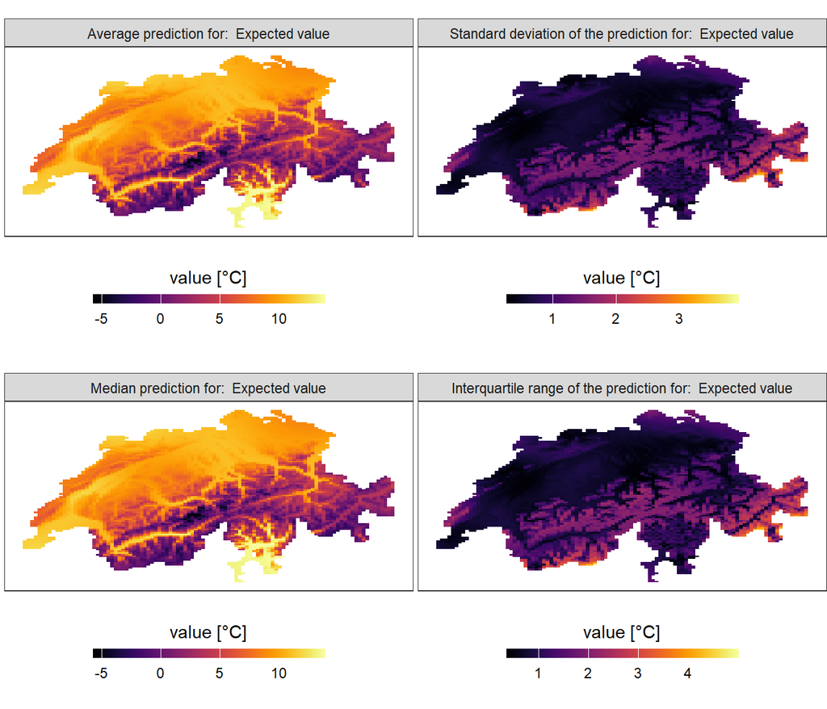

Summary of the SLGP probabilistic predictions for the expected temperatures in Switzerland.

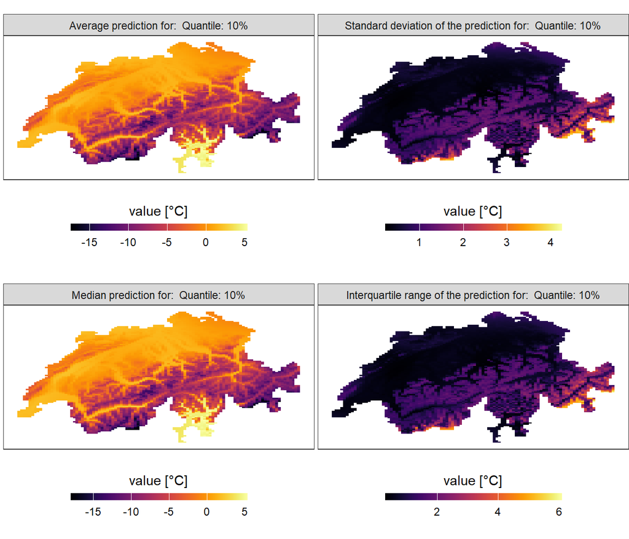

Summary of the SLGP probabilistic predictions for the 10% quantile of temperatures in Switzerland.

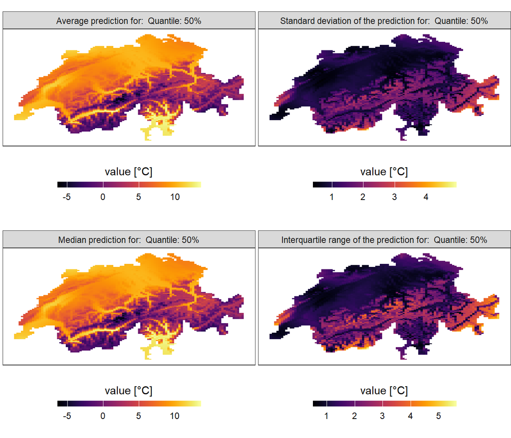

Summary of the SLGP probabilistic predictions for the 50% quantile of temperatures in Switzerland.

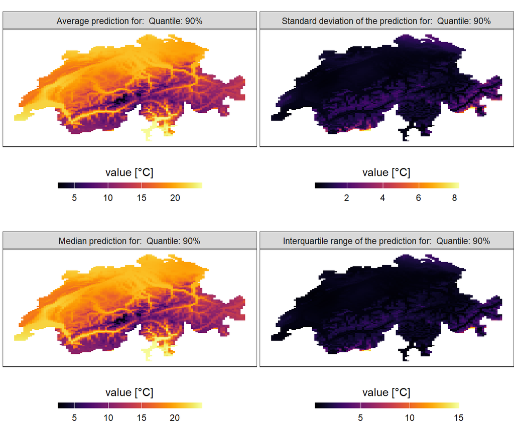

Summary of the SLGP probabilistic predictions for the 90% quantile of temperatures in Switzerland.

Meteorology, Swiss Federal Office of, and Climatology MeteoSwiss. 2019. “Climatological Network - Daily Values.” https://opendata.swiss/en/dataset/klimamessnetz-tageswerte.